# Estimating Biomoss Loss from Pagami Creek Fire

Alexander Graeff

2026-03-18

# Goal

Summarize biomass data per forest type for reference and burn plots: calculate an average biomass per forest type and then take the difference between reference plots and burns plots within a forest type to estimate the amount of biomass lost from the burn.

# Create Functions for Repeated Code

```r
# count the number of plots in groups

  group_count <- function(data, ...) {
    data %>%
      group_by(...) %>%
        summarize(n = n(), .groups = "keep") %>%
        ungroup() %>%
      pivot_wider(names_from = ref_burn, values_from = n, values_fill = 0)
  }

# standard error

  se <- function(var) {
    sd(var)/sqrt(length(var))
  }
```

# Import Data

Biomass calculations in the raw biomass data were made by Sue Lietz. Metadata is included in the file, but not all supporting data for biomass calculations are supplied in this directory. For more information about biomass calculations, contact the author.

forestTypes were generated with scripts/forestTypes.R

severity was generated in a different repository, but is essentially a compilation of plot names, crown burn severity, locations, and forest type classifications (different than the forestTypes imported separately).

```r
# biomass data ----

  biomass.raw <- read_xls(path = here("data/raw/pagami_DOMspecies_bio20131210.xls"),
                      sheet = "DOM_spp")

  head(biomass.raw)
```

| TP_IDENT | DOM_SPECIES | prop_ DOMspp | TOT_sum_BIOMASS | SUM_ABBA | SUM_BEPA | SUM_PIMA | SUM_POTR | SUM_PIGL | SUM_PIRE | SUM_PIBA | SUM_LALA | SUM_THOC | SUM_PIST | SUM_ACRU | SUM_FRNI | SUM_BEAL | SUM_HWSPP | SUM_SWSPP | SUM_UNKN | STEM_ABBA | STEM_BEPA | STEM_PIMA | STEM_POTR | STEM_PIGL | STEM_UNKN | STEM_PIRE | STEM_PIBA | STEM_PISPP | STEM_SASPP | … |
| --- | --- | --- | --- | --- | --- | --- | --- | --- | --- | --- | --- | --- | --- | --- | --- | --- | --- | --- | --- | --- | --- | --- | --- | --- | --- | --- | --- | --- | --- | --- |
| R-001-01 | POTR-ABBA-PIMA | 0.9202714 | 58.62192 | 20.980085 | 3.999077 | 4.651193 | 28.31680 | 0.0000000 | 0.000000 | 0.00000 | 0 | 0 | 0 | 0 | 0 | 0 | 0.6747692 | 0.000000 | 0.00000 | 20.552238 | 3.999077 | 4.277799 | 24.86289 | 0.00000 | 0.00000 | 0.000000 | 0.00000 | 0 | 0 | … |
| R-001-03 | ABBA-POTR-BEPA | 0.8443409 | 61.54444 | 27.277766 | 8.200444 | 0.000000 | 16.48628 | 0.4631798 | 0.000000 | 0.00000 | 0 | 0 | 0 | 0 | 0 | 0 | 4.6527159 | 4.464059 | 0.00000 | 27.277766 | 8.200444 | 0.000000 | 16.10530 | 0.00000 | 0.00000 | 0.000000 | 0.00000 | 0 | 0 | … |
| R-001-04 | POTR-PIGL-ABBA | 0.6913278 | 46.98842 | 6.596442 | 0.000000 | 1.706972 | 16.39183 | 9.4961328 | 0.000000 | 0.00000 | 0 | 0 | 0 | 0 | 0 | 0 | 0.5422475 | 3.689442 | 8.56536 | 4.801263 | 0.000000 | 0.000000 | 13.77880 | 6.06538 | 8.56536 | 0.000000 | 0.00000 | 0 | 0 | … |
| R-001-05 | PIRE | 1.0000000 | 112.96874 | 0.000000 | 0.000000 | 0.000000 | 0.00000 | 0.0000000 | 112.968744 | 0.00000 | 0 | 0 | 0 | 0 | 0 | NA | 0.0000000 | 0.000000 | 0.00000 | 0.000000 | 0.000000 | 0.000000 | 0.00000 | 0.00000 | 0.00000 | 112.968744 | 0.00000 | 0 | 0 | … |
| R-001-06 | PIBA-PIRE-ABBA | 1.0000000 | 49.62255 | 2.197612 | 0.000000 | 0.000000 | 0.00000 | 0.0000000 | 5.641646 | 41.78329 | 0 | 0 | 0 | 0 | 0 | NA | 0.0000000 | 0.000000 | 0.00000 | 2.197612 | 0.000000 | 0.000000 | 0.00000 | 0.00000 | 0.00000 | 5.641646 | 41.78329 | 0 | 0 | … |
| R-001-08 | ABBA-BEPA-PIMA | 0.7441651 | 58.45026 | 24.619466 | 12.845532 | 6.031647 | 0.00000 | 0.0000000 | 0.000000 | 0.00000 | 0 | 0 | 0 | 0 | 0 | 0 | 0.0000000 | 14.953617 | 0.00000 | 21.568698 | 10.564673 | 0.000000 | 0.00000 | 0.00000 | 0.00000 | 0.000000 | 0.00000 | 0 | 0 | … |

```r
# forest types ----

  forestTypes <- read_csv(file = here("data/reference/forestTypes.csv"),
                          show_col_types = FALSE,
                          locale = locale(encoding = "UTF-8")) %>%
    rename(forestType_code = code,  # rename some things so they are more understandable below
           forestType = name,
           forestType_group = group)

  head(forestTypes)
```

| tpIdent | forestType_code | forestType | forestType_group |
| --- | --- | --- | --- |
| R-001-01 | 901 | Aspen | Aspen-Birch |
| R-001-03 | 121 | Balsam fir | Spruce-Fir |
| R-001-04 | 901 | Aspen | Aspen-Birch |
| R-001-05 | 102 | Red pine | White-Red-Jack Pine |
| R-001-06 | 101 | Jack pine | White-Red-Jack Pine |
| R-001-08 | 121 | Balsam fir | Spruce-Fir |

```r
# severity ----

  severity <- read_csv(file = here("data/reference/severityCrn_forestType_plot.csv"),
                       show_col_types = FALSE)

  head(severity)
```

| TP_IDENT | ref_burn | FOR_TYPE_SF | TIMBER | SeverityIndex | crnSev | crnSev_sub | Easting | Northing |
| --- | --- | --- | --- | --- | --- | --- | --- | --- |
| R-001-01 | burn | Mixed | Mixed | 3.2 | 3 | 2 | 623643 | 5292373 |
| R-001-03 | burn | Aspen | Mixed | 3.2 | 3 | 2 | 624062 | 5292512 |
| R-001-04 | burn | Aspen | Mixed | 1.3 | 1 | 3 | 624148 | 5292484 |
| R-001-05 | burn | Red_Pine_Plant | Coniferous | 4.0 | 4 | NA | 627117 | 5295702 |
| R-001-06 | burn | Red_Pine_Plant | Coniferous | 4.0 | 4 | NA | 626677 | 5295546 |
| R-001-08 | burn | Spruce | Coniferous | 4.0 | 4 | NA | 626416 | 5294978 |

# Format Data

Here we pare down the biomass table and join the reference tables, then select columns relevant to the analyses. This is saved in data/processed as it is the data frame used to perform downstream analyses.

```r
  data <- biomass.raw %>%
    select(1, 4) %>%  # just take the total biomass and plot ID columns
    rename(tpIdent = 1, biomassTotal = 2) %>%  # rename them
    left_join(forestTypes, join_by(tpIdent)) %>%  # join the forest types data
    left_join(severity %>%  # join the severity data
                select(TP_IDENT, ref_burn, SeverityIndex, contains("crn")),  # (just a subset of it)
              join_by(tpIdent == TP_IDENT)) %>%
    select(tpIdent:ref_burn, crnSev)

  head(data)
```

| tpIdent | biomassTotal | forestType_code | forestType | forestType_group | ref_burn | crnSev |
| --- | --- | --- | --- | --- | --- | --- |
| R-001-01 | 58.62192 | 901 | Aspen | Aspen-Birch | burn | 3 |
| R-001-03 | 61.54444 | 121 | Balsam fir | Spruce-Fir | burn | 3 |
| R-001-04 | 46.98842 | 901 | Aspen | Aspen-Birch | burn | 1 |
| R-001-05 | 112.96874 | 102 | Red pine | White-Red-Jack Pine | burn | 4 |
| R-001-06 | 49.62255 | 101 | Jack pine | White-Red-Jack Pine | burn | 4 |
| R-001-08 | 58.45026 | 121 | Balsam fir | Spruce-Fir | burn | 4 |

# Check Group Sizes

At a minimum, for biomass comparisons, we need one reference plot in each forest type for which there are burn plots.

Indeed we do have at least one reference plot for each burn plot forest tyoe, however the sample sizes are pretty small where many have just 1.

```r
(d <- data %>%
    group_count(ref_burn, forestType) %>%
    rename(burnPlots = burn, referencePlots = reference))
```

| forestType | burnPlots | referencePlots |
| --- | --- | --- |
| Aspen | 25 | 4 |
| Balsam fir | 6 | 1 |
| Black spruce | 17 | 3 |
| Eastern white pine | 3 | 2 |
| Jack pine | 27 | 4 |
| Northern white-cedar | 3 | 2 |
| Other pine / hardwood | 5 | 1 |
| Paper birch | 17 | 4 |
| Red maple / upland | 1 | 1 |
| Red pine | 1 | 3 |

[output cut: 3 more lines]

Let’s look at the forest type groups as well.

There are 3 groups with pretty good sample sizes, and a couple with still-low sample sizes. Of course, with this, we lose a lot of forest type detail.

```r
  (d <- data %>%
    group_count(ref_burn, forestType_group) %>%
    rename(burnPlots = burn, referencePlots = reference))
```

| forestType_group | burnPlots | referencePlots |
| --- | --- | --- |
| Aspen-Birch | 42 | 8 |
| Maple-Beech-Birch | 1 | 1 |
| Oak-Pine | 5 | 1 |
| Spruce-Fir | 26 | 9 |
| White-Red-Jack Pine | 31 | 9 |
| Elm-Ash-Cottonwood | 0 | 1 |

For reference, we’ll generate tables with crown burn severity as well, since these plot counts are difficult to display on the charts which include crown burn severity.

For forest type…

```r
  (d <- data %>%
    group_count(ref_burn, forestType, crnSev) %>%
    rename(burnPlots = burn, referencePlots = reference,
           crownBurnSeverity = crnSev))
```

| forestType | crownBurnSeverity | burnPlots | referencePlots |
| --- | --- | --- | --- |
| Aspen | 1 | 5 | 0 |
| Aspen | 2 | 5 | 0 |
| Aspen | 3 | 5 | 0 |
| Aspen | 4 | 9 | 0 |
| Aspen | NA | 1 | 4 |
| Balsam fir | 3 | 3 | 0 |
| Balsam fir | 4 | 3 | 0 |
| Black spruce | 1 | 4 | 0 |
| Black spruce | 3 | 4 | 0 |
| Black spruce | 4 | 9 | 0 |

[output cut: 30 more lines]

and forest type groups.

```r
  (d <- data %>%
    group_count(ref_burn, forestType_group, crnSev) %>%
    rename(burnPlots = burn, referencePlots = reference,
           crownBurnSeverity = crnSev))
```

| forestType_group | crownBurnSeverity | burnPlots | referencePlots |
| --- | --- | --- | --- |
| Aspen-Birch | 1 | 6 | 0 |
| Aspen-Birch | 2 | 6 | 0 |
| Aspen-Birch | 3 | 9 | 0 |
| Aspen-Birch | 4 | 20 | 0 |
| Aspen-Birch | NA | 1 | 8 |
| Maple-Beech-Birch | 1 | 1 | 0 |
| Oak-Pine | 1 | 1 | 0 |
| Oak-Pine | 3 | 2 | 0 |
| Oak-Pine | 4 | 2 | 0 |
| Spruce-Fir | 1 | 4 | 0 |

[output cut: 11 more lines]

# Calculate Biomass by Plot Type and Forest Type

We will summarize the main data table to show average biomass by forest type and reference/burn.

```r
biomassMeans <- data %>%
    group_by(forestType, ref_burn) %>%
      summarize(biomassMean = mean(biomassTotal),
                se = se(biomassTotal),
                numPlots = n(),
                .groups = "drop")

  biomassMeans
```

| forestType | ref_burn | biomassMean | se | numPlots |
| --- | --- | --- | --- | --- |
| Aspen | burn | 66.09238 | 6.604903 | 25 |
| Aspen | reference | 85.39705 | 24.168484 | 4 |
| Balsam fir | burn | 44.05317 | 8.714034 | 6 |
| Balsam fir | reference | 64.29046 | NA | 1 |
| Black ash / American elm / red maple | reference | 75.71825 | NA | 1 |
| Black spruce | burn | 57.21705 | 4.455645 | 17 |
| Black spruce | reference | 84.26249 | 23.155481 | 3 |
| Eastern white pine | burn | 85.86522 | 20.116752 | 3 |
| Eastern white pine | reference | 92.77057 | 5.471481 | 2 |
| Jack pine | burn | 84.89764 | 6.537955 | 27 |

[output cut: 13 more lines]

```r
biomassMeans %>%
  rename("mean_biomass (mg/ha)" = biomassMean) %>%
  write_excel_csv(
      file = here("output/tables/biomassMeans_forestTypePlotType.csv")
    )

  rm(biomassMeans)
```

# Calulate Biomass Differences in Groups

We can calculate this a couple of different ways, but we should end up with roughly the same answer.

An intermediate step in this code allows us to see the estimated biomass lost individually for each plot. Otherwise, the calculations are probably more convoluted than the next step (Calculation B). But, it is more flexible as we will want to summarize by different groupings and may want to calculate averages directly, or leave plots with individual values (for use in boxplots).

```r
  biomass_diff_a <- function(data, x, y = NULL, sev_col = NULL, calculation) {  # define function with required x, optional y and sev_col
    sev_quo <- enquo(sev_col)  # capture sev_col as quosure (tidy-eval)
    has_sev <- !quo_is_null(sev_quo)  # flag: TRUE if sev_col was supplied

    a <- data %>%
      select(tpIdent, biomassTotal, forestType,  # keep needed columns
             forestType_group, ref_burn, crnSev) %>%
      group_by({{x}}) %>%  # group by primary variable x
        mutate(biomassMean_ref = mean(biomassTotal[ref_burn == "reference"])) %>%  # calculate mean biomass of reference plots within x
        ungroup() %>%  # remove grouping
      group_by({{x}}, {{y}}) %>%  # group by primary variable x and secondary variable y (if given)
        mutate(biomassDiff = if_else(condition = ref_burn == "burn",  # for burn rows, calculate biomassDiff...
                                     true = biomassMean_ref - biomassTotal,  # as ref mean biomass minus individual plot biomass
                                     false = NA)) %>%
        ungroup() # remove grouping

        if (calculation == "average") { a %>%  # if we want to calculate the calculation means across groups then
              filter(ref_burn == "burn") %>%  # keep only burn rows
              {
                if (has_sev) filter(., !is.na(!!sev_quo)) else .  # and if we're including crown severity then remove plots which don't have a crown severity
                } %>%  # optionally require non-missing sev_col
              group_by({{x}}, {{y}}) %>%  # group by x and y
                summarize(meanDiff = mean(biomassDiff), .groups = "keep") %>%  # compute mean difference per group (consider na.rm = TRUE)
                ungroup() %>%  # remove grouping
              arrange({{x}}, {{y}})
          }  # order by x then y
        else if (calculation == "unaveraged") { a %>%  # otherwise, we won't perform any calculations...
          filter(ref_burn != "reference") %>%  #... but we will remove all reference plots and...
          {
          if (has_sev) filter(., #... if we are summarizing by crown burn severity...
                              !is.na(!!sev_quo))  #... then we will remove any plots which don't have a severity value
          else .
          }
        }
        else if (calculation == "intermediate") {
          a
        }
      } # end function
```

Examples of Calculation A output.

```r
  data %>%
    biomass_diff_a(x = forestType,
                   y = NULL,
                   sev_col = NULL,
                   calculation  = "average")
```

| forestType | meanDiff |
| --- | --- |
| Aspen | 19.30467 |
| Balsam fir | 20.23729 |
| Black spruce | 27.04544 |
| Eastern white pine | 6.90535 |
| Jack pine | 13.01051 |
| Northern white-cedar | 49.39555 |
| Other pine / hardwood | 141.54723 |
| Paper birch | 22.50993 |
| Red maple / upland | -33.15368 |
| Red pine | 10.03283 |

If we average biomass for burn and reference plots, then subtract, it should be just about the same as the calculation above.

This code is probably more intuitive, (and is much simpler) but doesn’t include the separation of reference calculation so we can’t easily add crown severity as a grouping variable.

Indeed we get the same values, which is a good check, but we want the more flexible calculation going forward - so we’ll just use Calculation A.

```r
  biomass_diff_b <- function(data, ...) {
    data %>%
      group_by(...) %>%
        summarize(biomassMean = mean(biomassTotal),
                  .groups = "keep") %>%
        ungroup() %>%
      pivot_wider(names_from = ref_burn,
                  names_glue = "{ref_burn}_biomass",
                  values_from = biomassMean,
                  values_fill = 0) %>%
      mutate(meanBiomassDiff = reference_biomass - burn_biomass)
  }
```

Example Calculation B output.

```r
  data %>%
    biomass_diff_b(ref_burn, forestType)
```

| forestType | burn_biomass | reference_biomass | meanBiomassDiff |
| --- | --- | --- | --- |
| Aspen | 66.09238 | 85.39705 | 19.30467 |
| Balsam fir | 44.05317 | 64.29046 | 20.23729 |
| Black spruce | 57.21705 | 84.26249 | 27.04544 |
| Eastern white pine | 85.86522 | 92.77057 | 6.90535 |
| Jack pine | 84.89764 | 97.90814 | 13.01051 |
| Northern white-cedar | 92.76594 | 142.16148 | 49.39555 |
| Other pine / hardwood | 75.96084 | 217.50807 | 141.54723 |
| Paper birch | 54.79826 | 77.30819 | 22.50993 |
| Red maple / upland | 90.37504 | 57.22136 | -33.15368 |
| Red pine | 112.96874 | 123.00158 | 10.03283 |

[output cut: 3 more lines]

# Save Data Tables

We will hard save the summarized data tables as companions to the visualized data below.

```r
# biomass loss for each plot ----

  data %>%
    biomass_diff_a(x = forestType,
                   y = NULL,
                   sev_col = NULL,
                   calculation  = "intermediate") %>%
    rename("biomassTotal (mg/ha)" = biomassTotal,
           "biomassLoss (mg/ha)" = biomassDiff,
           crownBurnSeverity = crnSev,
           "mean_biomass_ref (mg/ha)" = biomassMean_ref) %>%
  write_csv(file = here("output/tables/biomassLoss_plot.csv"))

# average biomass differences from reference plots in forest types ----

  data %>%
    biomass_diff_a(x = forestType,
                   y = NULL,
                   sev_col = NULL,
                   calculation  = "average") %>%
    rename("mean_biomassLoss (mg/ha)" = meanDiff) %>%
  write_csv(file = here("output/tables/biomassLoss_forestType.csv"))

# average biomass differences from reference plots in forest type groups ----

  data %>%
    biomass_diff_a(x = forestType_group,
                   y = NULL,
                   sev_col = NULL,
                   calculation  = "average") %>%
    rename("mean_biomassLoss (mg/ha)" = meanDiff) %>%
    write_csv(file = here("output/tables/biomassLoss_forestTypeGroup.csv"))


# average biomass differences from reference plots in forest type by crown burn severity ----

  data %>%
    biomass_diff_a(x = forestType,
                   y = crnSev,
                   sev_col = crnSev,
                   calculation  = "average") %>%
    rename("mean_biomassLoss (mg/ha)" = meanDiff,
           crownBurnSeverity = crnSev) %>%
    write_csv(file = here("output/tables/biomassLoss_forestTypeGroupBurnSeverity.csv"))


# average biomass differences from reference plots in forest type groups by crown burn severity ----

  data %>%
    biomass_diff_a(x = forestType_group,
                   y = crnSev,
                   sev_col = crnSev,
                   calculation  = "average") %>%
    rename("mean_biomassLoss (mg/ha)" = meanDiff,
           crownBurnSeverity = crnSev) %>%
    write_csv(file = here("output/tables/biomassLoss_forestTypeGroupBurnSeverity.csv"))
```

# Visualize

For visualization, we summarize the data for plotting using the biomass_diff_a function.

## By Forest Type

### Column Chart

```r
# generate a table to label number of plots ----

  nLabs <- data %>%
    n_labs(forestType, ref_burn) %>%
    filter(ref_burn == "burn")

# perform calculations ----

  pData <- data %>%
    biomass_diff_a(x = forestType,
                   y = NULL,
                   sev_col = NULL,
                   calculation  = "average")

  pData
```

| forestType | meanDiff |
| --- | --- |
| Aspen | 19.30467 |
| Balsam fir | 20.23729 |
| Black spruce | 27.04544 |
| Eastern white pine | 6.90535 |
| Jack pine | 13.01051 |
| Northern white-cedar | 49.39555 |
| Other pine / hardwood | 141.54723 |
| Paper birch | 22.50993 |
| Red maple / upland | -33.15368 |
| Red pine | 10.03283 |

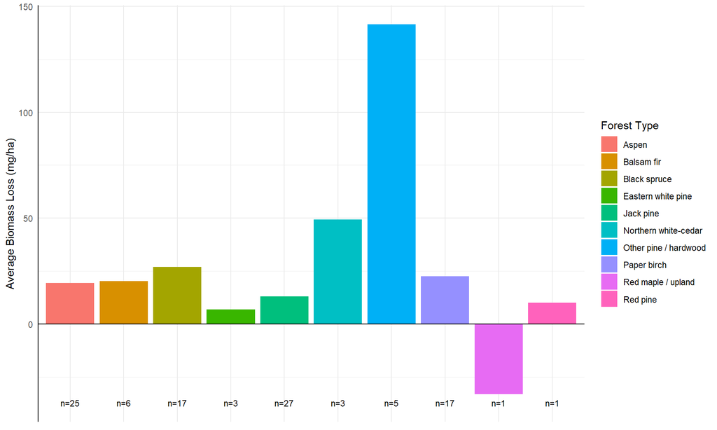

```r
# plot ----

  pData %>%
    ggplot(mapping = aes(x = forestType, y = meanDiff, fill = forestType)) +
      geom_col() +
      theme_minimal() +
      theme(axis.title.x = element_blank(),
            axis.text.x = element_blank(),
            axis.ticks.x = element_blank(),
            axis.line.y = element_line(color = "black", linewidth = 0.5)) +
      geom_hline(yintercept = 0) +
      labs(y = "Average Biomass Loss (mg/ha)",
           fill = "Forest Type") +
      n_labs_plotter(x = forestType,
                     sourceY = meanDiff,
                     yCorr = 4,
                     size = 3)
```

Figure 1. Average biomass loss across plots in each of several forest types, calculated as the average biomass in burn plots in each forest type subtracted from the average biomass in reference plots in each forest type. Forest types were calculated following Forest Inventory and Analysis guidelines, but using biomass as a proxy. Labels below each bar indicate the number of plots in each group.

### Box Plot

For boxplots, we skip the averaging step in the function.

```r
# generate a table to label number of plots ----

  nLabs <- data %>%
    n_labs(forestType, ref_burn) %>%
    filter(ref_burn == "burn")

# perform calculations ----

  pData <- data %>%
    biomass_diff_a(x = forestType,
                   y = NULL,
                   sev_col = NULL,
                   calculation  = "unaveraged")

  pData
```

| tpIdent | biomassTotal | forestType | forestType_group | ref_burn | crnSev | biomassMean_ref | biomassDiff |
| --- | --- | --- | --- | --- | --- | --- | --- |
| R-001-01 | 58.621920 | Aspen | Aspen-Birch | burn | 3 | 85.39705 | 26.775127 |
| R-001-03 | 61.544441 | Balsam fir | Spruce-Fir | burn | 3 | 64.29046 | 2.746021 |
| R-001-04 | 46.988423 | Aspen | Aspen-Birch | burn | 1 | 85.39705 | 38.408624 |
| R-001-05 | 112.968744 | Red pine | White-Red-Jack Pine | burn | 4 | 123.00158 | 10.032832 |
| R-001-06 | 49.622546 | Jack pine | White-Red-Jack Pine | burn | 4 | 97.90814 | 48.285597 |
| R-001-08 | 58.450263 | Balsam fir | Spruce-Fir | burn | 4 | 64.29046 | 5.840200 |
| R-001-09 | 43.553616 | Paper birch | Aspen-Birch | burn | 4 | 77.30819 | 33.754573 |
| R-001-11 | 41.820403 | Paper birch | Aspen-Birch | burn | 4 | 77.30819 | 35.487785 |
| R-001-12 | 19.576557 | Black spruce | Spruce-Fir | burn | 1 | 84.26249 | 64.685938 |
| T-000-01 | 27.045733 | Other pine / hardwood | Oak-Pine | burn | 4 | 217.50807 | 190.462340 |

[output cut: 95 more lines]

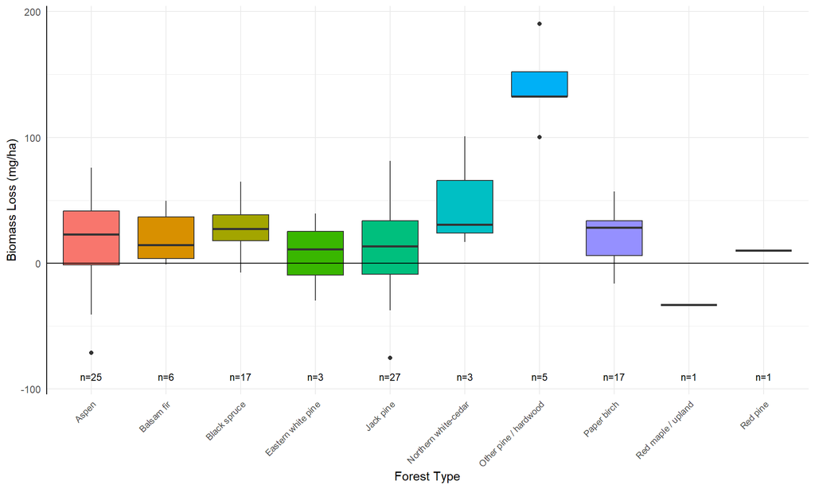

```r
# plot ----

  pData %>%
    ggplot(mapping = aes(x = forestType, y = biomassDiff, fill = forestType)) +
      geom_boxplot() +
      theme_minimal() +
      theme(axis.line.y = element_line(color = "black", linewidth = 0.5),
            axis.text.x = element_text(angle = 45,
                                       vjust = 1,
                                       hjust = 1,
                                       size = rel(.9)),
            legend.position = "none") +
      geom_hline(yintercept = 0) +
      labs(y = "Biomass Loss (mg/ha)",
           x = "Forest Type") +
      n_labs_plotter(x = forestType,
                     sourceY = biomassDiff,
                     yCorr = 15,
                     size = 3)
```

Figure 2. Biomass loss across plots in each of several forest types, calculated as the biomass in each burn plot in each forest type subtracted from the average biomass in reference plots in each forest type. Forest types were calculated following Forest Inventory and Analysis guidelines, but using biomass as a proxy. Labels below each bar indicate the number of plots in each group.

## By Forest Type Groups

We’ll do the same thing as above but with the forest type groups.

### Column Chart

```r
# generate a table to label number of plots ----

  nLabs <- data %>%
    n_labs(forestType_group, ref_burn) %>%
    filter(ref_burn == "burn")

# perform calculations ----

  pData <- data %>%
    biomass_diff_a(x = forestType_group,
                   y = NULL,
                   sev_col = NULL,
                   calculation  = "average")

  pData
```

| forestType_group | meanDiff |
| --- | --- |
| Aspen-Birch | 19.83167 |
| Maple-Beech-Birch | -33.15368 |
| Oak-Pine | 141.54723 |
| Spruce-Fir | 33.15778 |
| White-Red-Jack Pine | 19.23414 |

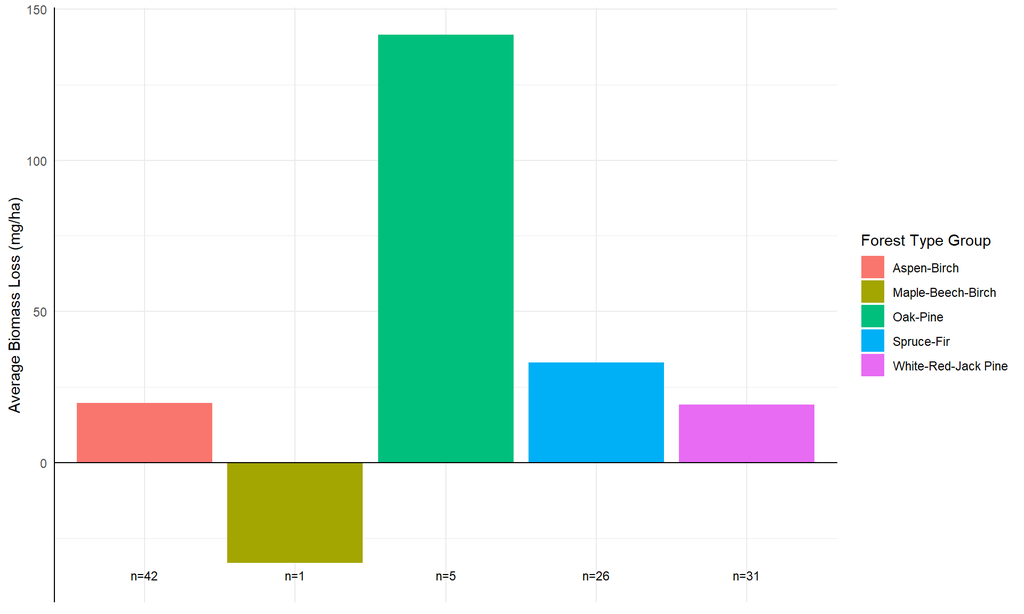

```r
# plot ----

  pData %>%
    ggplot(mapping = aes(x = forestType_group,
                         y = meanDiff,
                         fill = forestType_group)) +
      geom_col() +
      theme_minimal() +
      theme(axis.title.x = element_blank(),
            axis.text.x = element_blank(),
            axis.ticks.x = element_blank(),
            axis.line.y = element_line(color = "black", linewidth = 0.5)) +
      geom_hline(yintercept = 0) +
      labs(y = "Average Biomass Loss (mg/ha)",
           fill = "Forest Type Group") +
      n_labs_plotter(x = forestType_group,
                     sourceY = meanDiff,
                     yCorr = 4,
                     size = 3)
```

Figure 3. Average biomass loss across plots in forest types groups calculated as the average biomass in burn plots in each forest type group subtracted from the average biomass in reference plots in each forest type group. Forest type groups were calculated following Forest Inventory and Analysis guidelines, but using biomass as a proxy. Labels below each bar indicate the number of plots in each group.

### Box Plot

```r
# generate a table to label number of plots ----

  nLabs <- data %>%
    n_labs(forestType_group, ref_burn) %>%
    filter(ref_burn == "burn")

# perform calculations ----

  pData <- data %>%
    biomass_diff_a(x = forestType_group,
                   y = NULL,
                   sev_col = NULL,
                   calculation  = "unaveraged")

  pData
```

| tpIdent | biomassTotal | forestType | forestType_group | ref_burn | crnSev | biomassMean_ref | biomassDiff |
| --- | --- | --- | --- | --- | --- | --- | --- |
| R-001-01 | 58.621920 | Aspen | Aspen-Birch | burn | 3 | 81.35262 | 22.7306978 |
| R-001-03 | 61.544441 | Balsam fir | Spruce-Fir | burn | 3 | 91.43881 | 29.8943685 |
| R-001-04 | 46.988423 | Aspen | Aspen-Birch | burn | 1 | 81.35262 | 34.3641946 |
| R-001-05 | 112.968744 | Red pine | White-Red-Jack Pine | burn | 4 | 105.13094 | -7.8378064 |
| R-001-06 | 49.622546 | Jack pine | White-Red-Jack Pine | burn | 4 | 105.13094 | 55.5083917 |
| R-001-08 | 58.450263 | Balsam fir | Spruce-Fir | burn | 4 | 91.43881 | 32.9885471 |
| R-001-09 | 43.553616 | Paper birch | Aspen-Birch | burn | 4 | 81.35262 | 37.7990020 |
| R-001-11 | 41.820403 | Paper birch | Aspen-Birch | burn | 4 | 81.35262 | 39.5322148 |
| R-001-12 | 19.576557 | Black spruce | Spruce-Fir | burn | 1 | 91.43881 | 71.8622531 |
| T-000-01 | 27.045733 | Other pine / hardwood | Oak-Pine | burn | 4 | 217.50807 | 190.4623395 |

[output cut: 95 more lines]

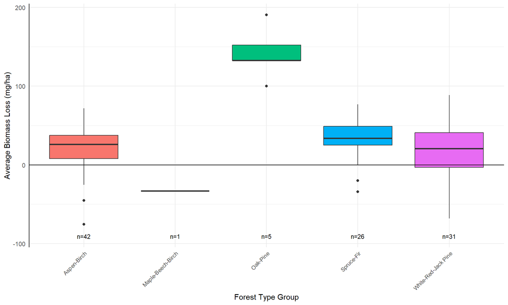

```r
# plot ----

  pData %>%
    ggplot(mapping = aes(x = forestType_group,
                         y = biomassDiff,
                         fill = forestType_group)) +
      geom_boxplot() +
      theme_minimal() +
      theme(axis.line.y = element_line(color = "black", linewidth = 0.5),
            axis.text.x = element_text(angle = 45,
                                       vjust = 1,
                                       hjust = 1,
                                       size = rel(.9)),
            legend.position = "none") +
      geom_hline(yintercept = 0) +
      labs(y = "Average Biomass Loss (mg/ha)",
           x = "Forest Type Group")  +
        n_labs_plotter(x = forestType_group,
                       sourceY = biomassDiff,
                       yCorr = 15,
                       size = 3)
```

Figure 4. Biomass loss across plots in forest type groups, calculated as the biomass in each burn plot in each forest type group subtracted from the average biomass in reference plots in each forest type. Forest type groups were calculated following Forest Inventory and Analysis guidelines, but using biomass as a proxy. Labels below each bar indicate the number of plots in each group.

## By Forest Type and Crown Burn Severity

```r
# perform calculations ----

  pData <- data %>%
    biomass_diff_a(x = forestType,
                   y = crnSev,
                   sev_col = crnSev,
                   calculation  = "average")

  pData
```

| forestType | crnSev | meanDiff |
| --- | --- | --- |
| Aspen | 1 | 11.230477 |
| Aspen | 2 | 21.165907 |
| Aspen | 3 | 15.727171 |
| Aspen | 4 | 31.450891 |
| Balsam fir | 3 | 22.377029 |
| Balsam fir | 4 | 18.097557 |
| Black spruce | 1 | 39.235574 |
| Black spruce | 3 | 16.586100 |
| Black spruce | 4 | 26.276203 |
| Eastern white pine | 1 | 10.921049 |

[output cut: 17 more lines]

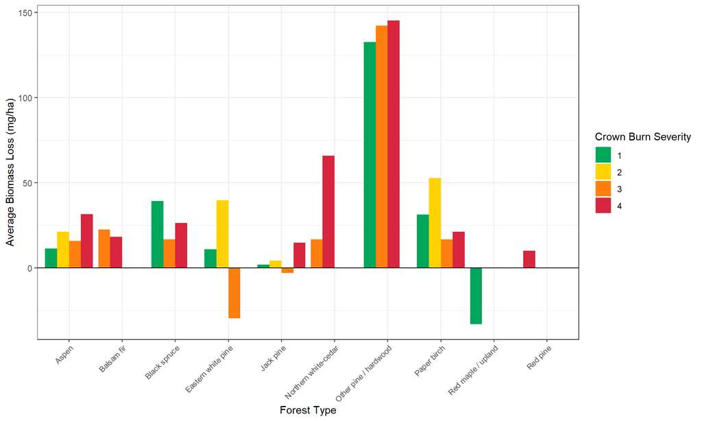

```r
# plot ----

  pData %>%
    ggplot(mapping = aes(x = forestType,
                         y = meanDiff,
                         fill = as.character(crnSev))) +
      geom_col(position = position_dodge(preserve = "single")) +
      scale_fill_manual(values = severity.colors) +
      geom_hline(yintercept = 0) +
      theme_bw() +
      theme(axis.text.x = element_text(angle = 45,
                                       vjust = 1,
                                       hjust = 1,
                                       size = rel(.9))) +
    labs(x = "Forest Type",
         y = "Average Biomass Loss (mg/ha)",
         fill = "Crown Burn Severity")
```

Figure 5. Average biomass loss across plots in each of several forest types and by plot crown burn severity, calculated as the biomass of each group subtracted from the average biomass in reference plots for each group. Forest types were calculated following Forest Inventory and Analysis guidelines, but using biomass as a proxy.

```r
# perform calculations ----

  pData <- data %>%
    biomass_diff_a(x = forestType_group,
                   y = crnSev,
                   sev_col = crnSev,
                   calculation  = "average")

  pData
```

| forestType_group | crnSev | meanDiff |
| --- | --- | --- |
| Aspen-Birch | 1 | 11.861848 |
| Aspen-Birch | 2 | 23.716315 |
| Aspen-Birch | 3 | 15.738006 |
| Aspen-Birch | 4 | 26.146126 |
| Maple-Beech-Birch | 1 | -33.153675 |
| Oak-Pine | 1 | 132.537632 |
| Oak-Pine | 3 | 142.281599 |
| Oak-Pine | 4 | 145.317662 |
| Spruce-Fir | 1 | 46.411889 |
| Spruce-Fir | 3 | 26.203320 |

[output cut: 5 more lines]

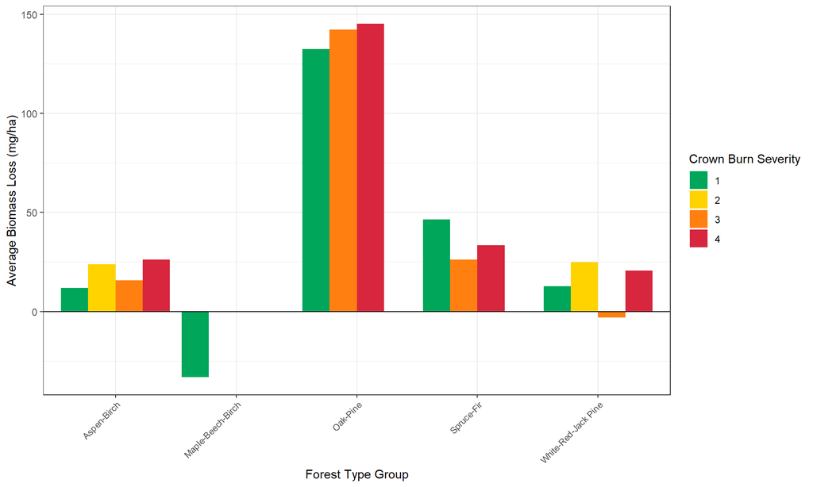

```r
# plot ----

  pData %>%
    ggplot(mapping = aes(x = forestType_group,
                         y = meanDiff,
                         fill = as.character(crnSev))) +
      geom_col(position = position_dodge(preserve = "single")) +
      scale_fill_manual(values = severity.colors) +
      geom_hline(yintercept = 0) +
      theme_bw() +
      theme(axis.text.x = element_text(angle = 45,
                                       vjust = 1,
                                       hjust = 1,
                                       size = rel(.9))) +
    labs(x = "Forest Type Group",
         y = "Average Biomass Loss (mg/ha)",
         fill = "Crown Burn Severity")
```

Figure 6. Average biomass loss across plots in each of several forest type groups and by plot crown burn severity, calculated as the biomass of each group subtracted from the average biomass in reference plots for each group. Forest types were calculated following Forest Inventory and Analysis guidelines, but using biomass as a proxy.

# Compile Output Columns for Definitions File

```r
  filesList <- list.files(path = here("output/tables"),  # create a list of all of the data files
                          pattern = "*.csv",
                          full.names = TRUE)

  dataList <- filesList %>%
    map(.f = ~read_csv(.x, show_col_types = FALSE))

  names(dataList) <- basename(filesList)  # set the names of each table in the data list to the year (extracted from the file name)

  a <- dataList %>%  # read the detail sheet from each file into a list
    map(.f = ~ colnames(.x)) %>%
    list_c() %>%
    unique() %>%
    tibble(column = ., definiton = "")

  a
```

| column | definiton |
| --- | --- |
| forestType |  |
| mean_biomassLoss (mg/ha) |  |
| forestType_group |  |
| crownBurnSeverity |  |
| tpIdent |  |
| biomassTotal (mg/ha) |  |
| ref_burn |  |
| mean_biomass_ref (mg/ha) |  |
| biomassLoss (mg/ha) |  |
| mean_biomass (mg/ha) |  |

[output cut: 4 more lines]

```r
  a %>%
    write_csv(file = here("cols.csv"))
```